# Лабораторна робота № 6

### Завдання 10.2б — замкніть цикл

Пояснення моделі має **повертатись у підготовку даних**. PDP показав форму — тепер побудуйте ознаку цієї форми і виміряйте, що вона дала.

Зробіть це для **логістичної регресії**, а не для лісу: ліс цю форму і так бачив, а лінійна модель — ні. Порівняння має бути парним.

```python
# 1) значення, при якому ризик за PDP лісу мінімальний
age_grid, age_avg = pdp_rf['grid_values'][0], pdp_rf['average'][0]
AGE_MIN = float(round(age_grid[np.argmin(age_avg)]))
print('мінімум PDP лісу при віці ~', AGE_MIN)

# 2) ознака «квадрат відхилення від цього значення»
X6 = FINAL_X.copy()
X6['вік_кв_відхилення'] = (X6[NONLINEAR_FEATURE] - AGE_MIN) ** 2

# 3) парне порівняння логістичної регресії з нею і без неї (ті самі поділи cv)
auc_lin_base = cross_val_score(make_pipe(FINAL_X, logreg()), FINAL_X, y, cv=cv, scoring='roc_auc')
auc_lin_quad = cross_val_score(make_pipe(X6, logreg()),      X6,      y, cv=cv, scoring='roc_auc')
m, h = paired(auc_lin_base, auc_lin_quad)
print('логістична без ознаки: AUC %.3f ± %.3f' % (auc_lin_base.mean(), auc_lin_base.std()))
print('логістична з ознакою : AUC %.3f ± %.3f' % (auc_lin_quad.mean(), auc_lin_quad.std()))
print('приріст: %+0.4f ± %.4f   %s' % (m, h, 'значуще' if abs(m) > h else 'у межах шуму'))
```

```
мінімум PDP лісу при віці ~ 35.0
логістична без ознаки: AUC 0.820 ± 0.024
логістична з ознакою : AUC 0.846 ± 0.027
приріст: +0.0267 ± 0.0058   значуще
```

```python
QUAD_GAIN = float(m)     # приріст AUC лінійної моделі від нової ознаки
assert QUAD_GAIN is not None
print('приріст від сконструйованої ознаки: %+.4f' % QUAD_GAIN)
```

```
приріст від сконструйованої ознаки: +0.0267
```

### Завдання 10.3 — ТРЕТЯ ХИБНА ІНТЕРПРЕТАЦІЯ

PDP **усереднює по всій вибірці**. Якщо ознака діє на різні групи клієнтів по-різному, усереднення це приховає: протилежні ефекти взаємно погасяться, і крива вийде майже пласкою.

Перевірте це на парі «знижка — стаж обслуговування».

1. Побудуйте звичайний PDP для `знижка_відсоток` по всій вибірці.
2. Побудуйте **ICE** (`kind='individual'`) — по кривій на кожного клієнта. Подивіться, чи всі криві йдуть в один бік.
3. Побудуйте PDP для `знижка_відсоток` **окремо** на двох підвибірках: клієнти зі стажем до 24 місяців і понад 24 місяці.

> **Важливо.** PDP і ICE рахуйте на **повній** матриці `FINAL_X`, а не на `Xte`. Це опитування моделі, а не оцінювання якості, тож використовувати всі рядки коректно — а на 30 % рядків підгрупи виходять замалі й криві стають шумними.

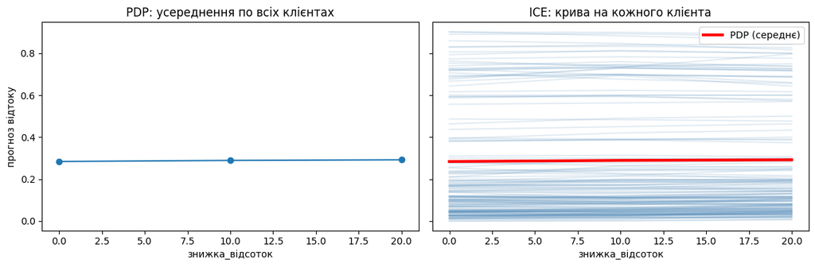

```
частка клієнтів, у яких більша знижка підвищує прогноз: 0.63
середня зміна +0.0081, розкид (σ) 0.0251
```

```python
# 1) звичайний PDP і 2) ICE для 'знижка_відсоток' — на ПОВНІЙ матриці FINAL_X
D = 'знижка_відсоток'
res = partial_dependence(model, FINAL_X, [D], kind='both', grid_resolution=20)
grid = res['grid_values'][0]
ice  = res['individual'][0]          # (n_клієнтів, n_значень_сітки)
pdp_all = res['average'][0]

fig, axes = plt.subplots(1, 2, figsize=(12, 4), sharey=True)
axes[0].plot(grid, pdp_all, marker='o')
axes[0].set_title('PDP: усереднення по всіх клієнтах')
rng = np.random.RandomState(SEED)
for k in rng.choice(len(ice), 150, replace=False):
    axes[1].plot(grid, ice[k], color='steelblue', alpha=0.15)
axes[1].plot(grid, pdp_all, color='red', lw=3, label='PDP (середнє)')
axes[1].set_title('ICE: крива на кожного клієнта'); axes[1].legend()
for a in axes: a.set_xlabel(D)
axes[0].set_ylabel('прогноз відтоку')
plt.tight_layout(); plt.show()

delta = ice[:, -1] - ice[:, 0]
print('частка клієнтів, у яких більша знижка підвищує прогноз: %.2f' % (delta > 0).mean())
print('середня зміна %+.4f, розкид (σ) %.4f' % (delta.mean(), delta.std()))
```

```
стаж ≤ 24 міс [0.324 0.337]
стаж > 24 міс [0.224 0.225]
```

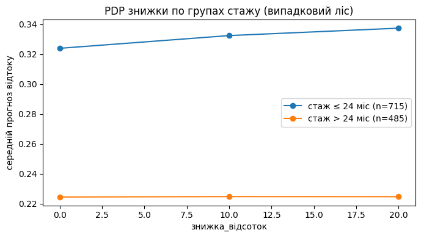

```python
# 3) PDP для знижки окремо: стаж до 24 місяців і понад 24
tenure = FINAL_X['місяців_обслуговування']
fig, ax = plt.subplots(figsize=(7, 4))
for lab, mask in [('стаж ≤ 24 міс', tenure <= 24), ('стаж > 24 міс', tenure > 24)]:
    r = partial_dependence(model, FINAL_X[mask], [D], kind='average', grid_resolution=20)
    ax.plot(r['grid_values'][0], r['average'][0], marker='o', label='%s (n=%d)' % (lab, mask.sum()))
    print(lab, np.round(r['average'][0][[0, -1]], 3))
ax.set_xlabel(D); ax.set_ylabel('середній прогноз відтоку'); ax.legend()
ax.set_title('PDP знижки по групах стажу (випадковий ліс)')
plt.tight_layout(); plt.show()
```

### Завдання 10.3б — звірка з сирими даними

Перш ніж вірити графіку, перевірте його по сирій таблиці: порахуйте **емпіричну** частку відтоку за розміром знижки окремо в кожній групі стажу. Модель має відтворювати ту саму картину. Якщо не відтворює — питання не до PDP, а до моделі.

```python
# емпірична частка відтоку за сирою таблицею
grp = np.where(raw['місяців_обслуговування'] <= 24, 'стаж ≤ 24', 'стаж > 24')
emp = (raw.assign(група=grp)
          .pivot_table(index='група', columns=D, values=TARGET, aggfunc=['mean', 'size'])
          .round(3))
display(emp)
```

| знижка_відсоток група | mean 0 | mean 10 | mean 20 | size 0 | size 10 | size 20 |
| --- | --- | --- | --- | --- | --- | --- |
| стаж > 24 | 0.235 | 0.142 | 0.069 | 221 | 134 | 130 |
| стаж ≤ 24 | 0.269 | 0.376 | 0.480 | 290 | 250 | 175 |

```
AUC на відкладеній частині: бустинг 0.798, ліс 0.796
стаж ≤ 24 міс [0.331 0.359]
стаж > 24 міс [0.205 0.196]
```

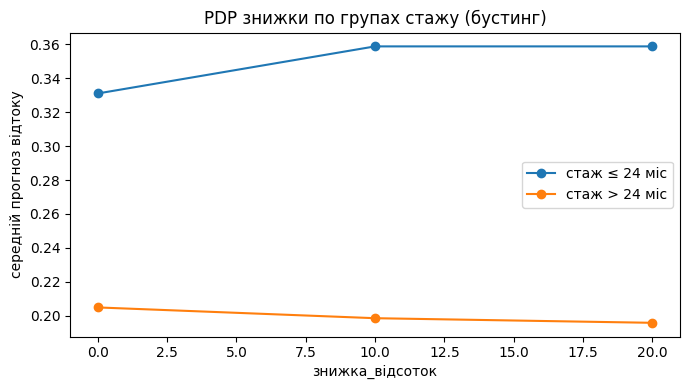

```python
# Додаткова перевірка: чи бачить цей зв'язок інша модель (гістограмний бустинг)?
hgb = make_pipe(FINAL_X, HistGradientBoostingClassifier(max_depth=3, learning_rate=0.05,
                                                        max_iter=200, random_state=SEED)).fit(Xtr, ytr)
print('AUC на відкладеній частині: бустинг %.3f, ліс %.3f' % (
    roc_auc_score(yte, hgb.predict_proba(Xte)[:, 1]), auc_hold))
fig, ax = plt.subplots(figsize=(7, 4))
for lab, mask in [('стаж ≤ 24 міс', tenure <= 24), ('стаж > 24 міс', tenure > 24)]:
    r = partial_dependence(hgb, FINAL_X[mask], [D], kind='average', grid_resolution=20)
    ax.plot(r['grid_values'][0], r['average'][0], marker='o', label=lab)
    print(lab, np.round(r['average'][0][[0, -1]], 3))
ax.set_xlabel(D); ax.set_ylabel('середній прогноз відтоку'); ax.legend()
ax.set_title('PDP знижки по групах стажу (бустинг)')
plt.tight_layout(); plt.show()
```

```python
INTERACTION_FOUND = 'За сирими даними знижка діє в протилежні боки. У клієнтів зі стажем до 24 місяців відтік зростає з 26,9 % без знижки до 37,6 % при знижці 10 % і 48,0 % при 20 %, а у клієнтів зі стажем понад 24 місяці падає з 23,5 % до 14,2 % і 6,9 %. По всій вибірці ефекти майже гасяться (25,4 % → 29,4 % → 30,5 %), тому PDP випадкового лісу майже пласкій (≈0,28 → 0,29), а ICE показує невеликий розкид (63 % кривих ідуть угору, σ зміни ≈0,025). Звірка з моделлю: ліс згладив взаємодію (≈0,32 → 0,34 у новачків і ≈0,22 → 0,22 у давніх клієнтів), бустинг відтворює напрям (новачки ≈0,33 → 0,36, давні ≈0,21 → 0,20), але слабше за сирі дані, тож тут обмеження — у моделі, а не в PDP.'
BUSINESS_ACTION = 'Знижку не можна роздавати всім підряд: для клієнтів зі стажем понад 24 місяці вона пов’язана зі значно нижчим відтоком (6,9 % при знижці 20 % проти 23,5 % без неї), тож утримувати їх знижкою має сенс; для новачків зв’язок обернений (48,0 % при 20 %), тобто знижка або не допомагає, або дається тим, хто вже збирається піти. Це спостережні дані без експерименту, тому перед масовим застосуванням потрібен A/B-тест хоча б на новачках.'
assert INTERACTION_FOUND and BUSINESS_ACTION
print(INTERACTION_FOUND)
print(BUSINESS_ACTION)
```

[output not shown]

> **Що тут сталося.** PDP відповідає на питання «як змінюється **середній** прогноз». Якщо ефект різноспрямований, середнє близьке до нуля при сильних ефектах у кожній групі. ICE показує окремі криві й робить розбіжність видимою; PDP по підгрупах показує її кількісно.